# Tarea 1 Parcial 2

Natividad Oswaldo Pérez Medina

2025-04-09

# Ejercicio 2

**a)** Simula series de tiempo de longitud 100 a partir de un modelo AR(1) con $\alpha$ igual a -0.9, -0.5, 0.5 y 0.9. Estima el parámetro de cada modelo y realiza predicciones de 1 a 10 pasos hacia adelante.

**b)** Simula series de tiempo de longitud 100 a partir de un modelo AR(1) con $\alpha$ igual a 1.01, 1.02 y 1.05. Estima los parámetros de estos modelos.

## Respuesta

### a)

```r
set.seed(1) # Para fijar una semilla
# Para los valores de alpha
alpha1 <- -0.9
alpha2 <- -0.5
alpha3 <- 0.5
alpha4 <- 0.9

# Preparando los vectores para cada serie
x1 <- x2 <- x3 <- x4 <- w <- rnorm(100)


# Para simular la serie 1
for (t in 3:100)
{
  x1[t] <-  alpha1 * x1[t - 1]  + w[t]
}

# Estimar el modelo AR(1)
modelo1 <- ar(x1, method = "mle")
para1 <- modelo1$ar # Parámetro 1
para1
```

```
## [1] -0.8732048
```

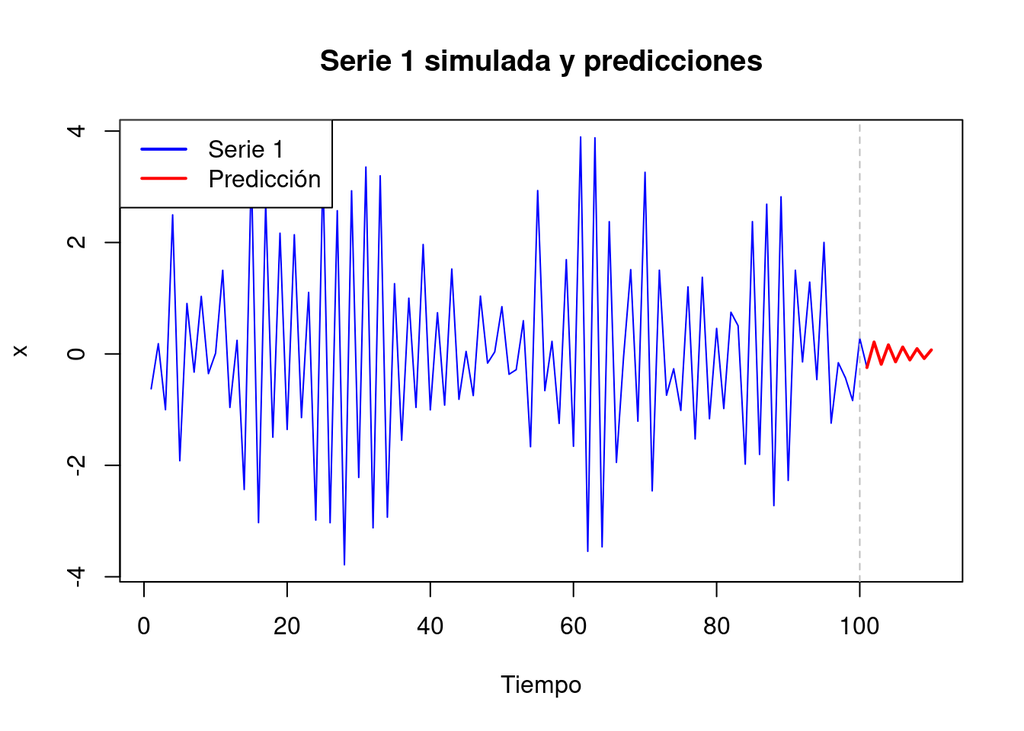

```r
# Predicciones manuales usando la fórmula AR(1)
preds1 <- numeric(10)
preds1[1] <- para1 * x1[100]
for (h in 2:10)
{
  preds1[h] <- para1 * preds1[h - 1]
}

# Para observar la serie 1 simulada y sus predicciones
n <- 100
Time <- 1:(n + 10)

# Combinar serie real y predicciones
serie_completa1 <- c(x1, preds1)

# Gráfica 1
plot(Time, serie_completa1, type = "l", col = "blue", ylim = range(serie_completa1),
     main = "Serie 1 simulada y predicciones",
     ylab = "x", xlab = "Tiempo")
abline(v = n, col = "gray", lty = 2)  # Línea vertical que separa lo observado de lo predicho
lines((n+1):(n+10), preds1, col = "red", lwd = 2)

legend("topleft", legend = c("Serie 1", "Predicción"),
       col = c("blue", "red"), lty = 1, lwd = 2)
```

```r
# Para simular la serie 2
for (t in 3:100)
{
  x2[t] <-  alpha2 * x2[t - 1]  + w[t]
}

# Estimar el modelo AR(1)
modelo2 <- ar(x2, method = "mle")
para2 <- modelo1$ar # Parámetro 2
para2
```

```
## [1] -0.8732048
```

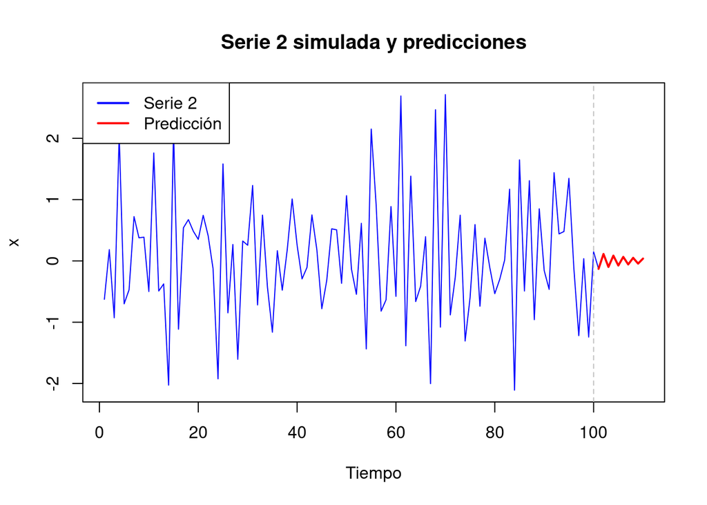

```r
# Predicciones manuales usando la fórmula AR(1)
preds2 <- numeric(10)
preds2[1] <- para2 * x2[100]
for (h in 2:10)
{
  preds2[h] <- para2 * preds2[h - 1]
}

# Para observar la serie 2 simulada y sus predicciones
n <- 100
Time <- 1:(n + 10)

# Combinar serie real y predicciones
serie_completa2 <- c(x2, preds2)

# Gráfica 2
plot(Time, serie_completa2, type = "l", col = "blue", ylim = range(serie_completa2),
     main = "Serie 2 simulada y predicciones",
     ylab = "x", xlab = "Tiempo")
abline(v = n, col = "gray", lty = 2)  # Línea vertical que separa lo observado de lo predicho
lines((n+1):(n+10), preds2, col = "red", lwd = 2)

legend("topleft", legend = c("Serie 2", "Predicción"),
       col = c("blue", "red"), lty = 1, lwd = 2)
```

```r
# Para simular la serie 3
for (t in 3:100)
{
  x3[t] <-  alpha3 * x3[t - 1]  + w[t]
}

# Estimar el modelo AR(1)
modelo3 <- ar(x3, method = "mle")
para3 <- modelo3$ar # Parámetro 3
para3
```

```
## [1] 0.4403361
```

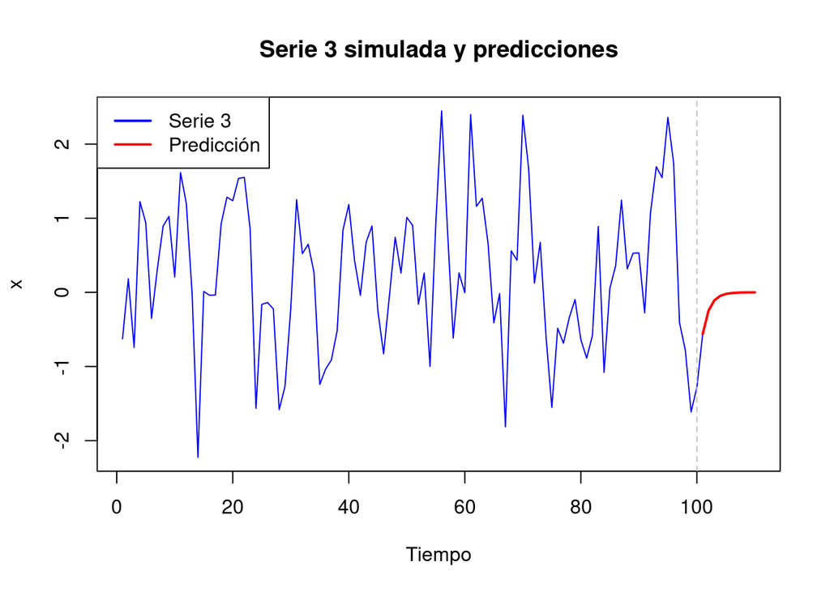

```r
# Predicciones manuales usando la fórmula AR(1)
preds3 <- numeric(10)
preds3[1] <- para3 * x3[100]
for (h in 2:10)
{
  preds3[h] <- para3 * preds3[h - 1]
}

# Para observar la serie 3 simulada y sus predicciones
n <- 100
Time <- 1:(n + 10)

# Combinar serie real y predicciones
serie_completa3 <- c(x3, preds3)

# Gráfica 3
plot(Time, serie_completa3, type = "l", col = "blue", ylim = range(serie_completa3),
     main = "Serie 3 simulada y predicciones",
     ylab = "x", xlab = "Tiempo")
abline(v = n, col = "gray", lty = 2)  # Línea vertical que separa lo observado de lo predicho
lines((n+1):(n+10), preds3, col = "red", lwd = 2)

legend("topleft", legend = c("Serie 3", "Predicción"),
       col = c("blue", "red"), lty = 1, lwd = 2)
```

```r
# Para simular la serie 4
for (t in 3:100)
{
  x4[t] <-  alpha4 * x4[t - 1]  + w[t]
}

# Estimar el modelo AR(1)
modelo4 <- ar(x4, method = "mle")
para4 <- modelo4$ar # Parámetro 4
para4
```

```
## [1] 0.7616663
```

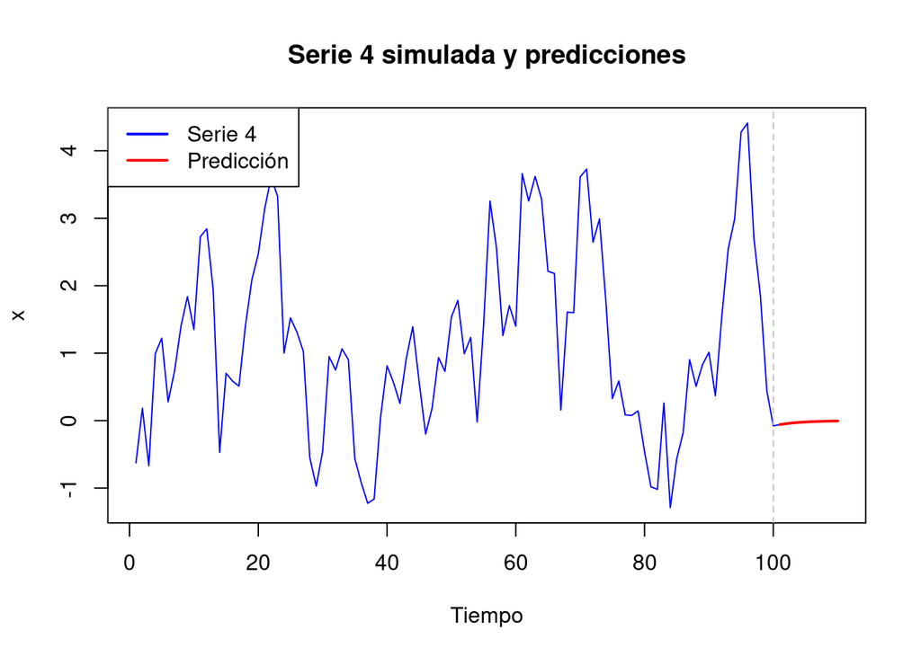

```r
# Predicciones manuales usando la fórmula AR(1)
preds4 <- numeric(10)
preds4[1] <- para4 * x4[100]
for (h in 2:10)
{
  preds4[h] <- para4 * preds4[h - 1]
}

# Para observar la serie simulada y sus predicciones
n <- 100
Time <- 1:(n + 10)

# Combinar serie real y predicciones
serie_completa4 <- c(x4, preds4)

# Gráfica 1
plot(Time, serie_completa4, type = "l", col = "blue", ylim = range(serie_completa4),
     main = "Serie 4 simulada y predicciones",
     ylab = "x", xlab = "Tiempo")
abline(v = n, col = "gray", lty = 2)  # Línea vertical que separa lo observado de lo predicho
lines((n+1):(n+10), preds4, col = "red", lwd = 2)

legend("topleft", legend = c("Serie 4", "Predicción"),
       col = c("blue", "red"), lty = 1, lwd = 2)
```

### b)

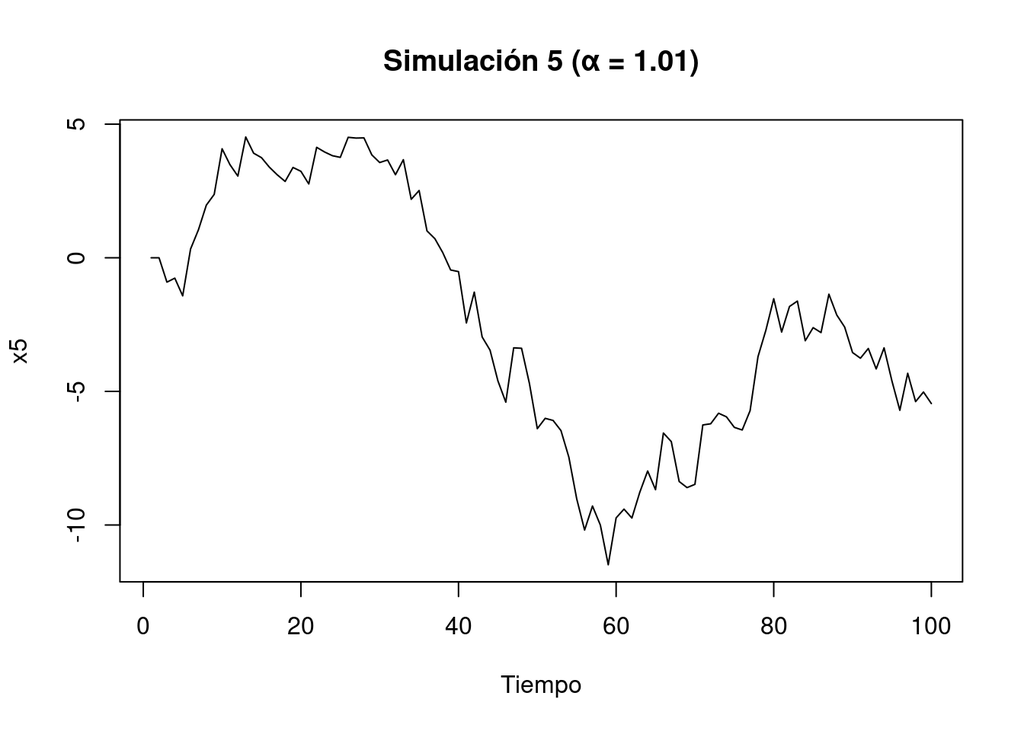

```r
# Valores de alpha
alpha5 <- 1.01
alpha6 <- 1.02
alpha7 <- 1.05

# Longitud de la serie
n <- 100

# Serie 5: alpha = 1.01
x5 <- numeric(n)
w5 <- rnorm(n)

for (t in 3:n) {
  x5[t] <- alpha5 * x5[t - 1] + w5[t]
}
plot(x5, type = "l", main = "Simulación 5 (α = 1.01)", ylab = "x5", xlab = "Tiempo")
```

```r
modelo5 <- ar(x5, method = "mle")
para5 <- modelo5$ar
para5
```

```
##  [1]  0.94758654 -0.03663605  0.10928672 -0.09377517  0.23915914 -0.14728359
##  [7]  0.14750591 -0.34203173  0.44574510 -0.31453844
```

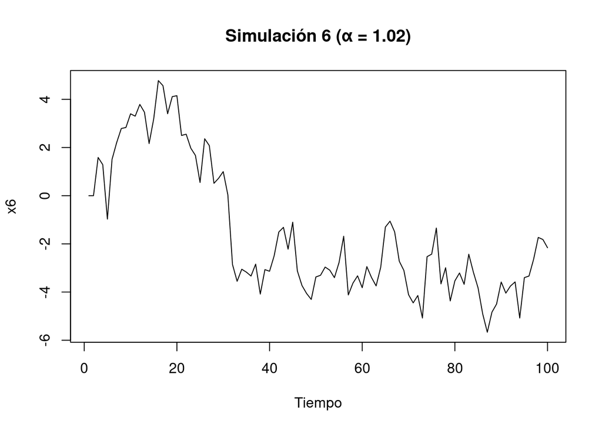

```r
# Serie 6: alpha = 1.02
x6 <- numeric(n)
w6 <- rnorm(n)

for (t in 3:n) {
  x6[t] <- alpha6 * x6[t - 1] + w6[t]
}
plot(x6, type = "l", main = "Simulación 6 (α = 1.02)", ylab = "x6", xlab = "Tiempo")
```

```r
modelo6 <- ar(x6, method = "mle")
para6 <- modelo6$ar
para6
```

```
## [1] 0.926418
```

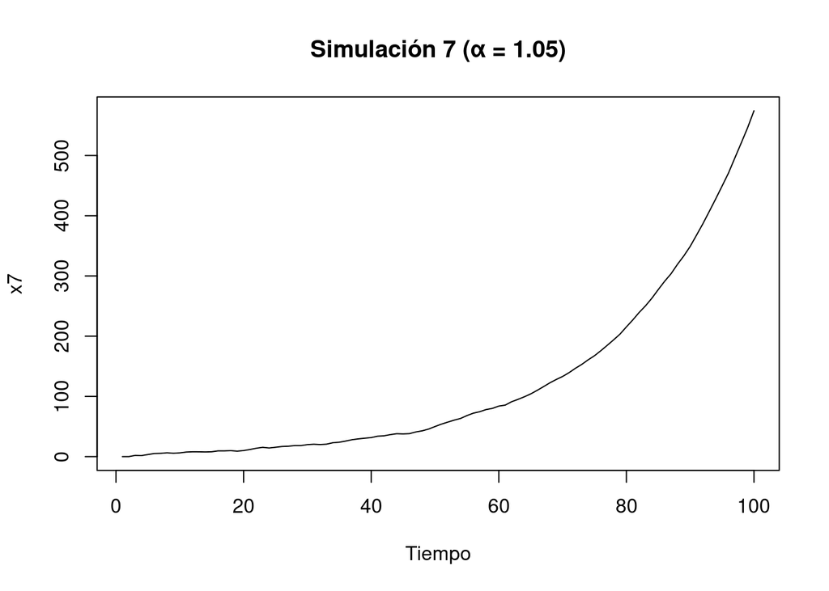

```r
# Serie 7: alpha = 1.05
x7 <- numeric(n)
w7 <- rnorm(n)

for (t in 3:n) {
  x7[t] <- alpha7 * x7[t - 1] + w7[t]
}
plot(x7, type = "l", main = "Simulación 7 (α = 1.05)", ylab = "x7", xlab = "Tiempo")
```

```r
modelo7 <- ar(x7, method = "mle")
para7 <- modelo7$ar
para7
```

```
## [1]  1.48959891 -0.11484385 -0.12811449 -0.15747403  0.01518819 -0.09457099
## [7] -0.14884954 -0.04459734  0.18345308
```

# Ejercicio 3

Un modelo AR(1) con media no nula $\mu$ puede expresarse de dos formas:

$$x_t - \mu = \alpha (x_{t-1} - \mu) + w_t \quad \text{o bien} \quad x_t =
\alpha_0 + \alpha_1 x_{t-1} + w_t$$

**a)** ¿Cuál es la relación entre los parámetros $\mu$ y $\alpha$, y los parámetros $\alpha_0$ y $\alpha_1$?  
**b)** Deduce una relación similar para un proceso AR(2) con media $\mu$.

## Respuesta

### a)

Comparando ambas expresiones, se puede deducir que:

$$\alpha_0 = \mu (1 - \alpha), \quad \alpha_1 = \alpha$$

Esto significa que el intercepto $\alpha_0$ en la forma con regresión captura la parte constante necesaria para que el modelo tenga media $\mu$.

### b)

Un modelo AR(2) con media $\mu$ se puede escribir como:

$$x_t - \mu = \alpha_1(x_{t-1} - \mu) + \alpha_2(x_{t-2} - \mu) + w_t$$

Reorganizando, se obtiene:

$$x_t = \alpha_1 x_{t-1} + \alpha_2 x_{t-2} + \mu (1 - \alpha_1 -
\alpha_2) + w_t$$

Por lo tanto, en su forma con intercepto:

$$x_t = \alpha_0 + \alpha_1 x_{t-1} + \alpha_2 x_{t-2} + w_t$$

donde:

$$\alpha_0 = \mu (1 - \alpha_1 - \alpha_2)$$

# Ejercicio 4

**a)** Simula una serie de tiempo de longitud 1000 para el siguiente modelo, proporcionando el código en R y colocando los datos simulados en un vector llamado `x`:

$$x_t = \frac{5}{6}x_{t-1} - \frac{1}{6}x_{t-2} + w_t \tag{4.25}$$

## Respuesta

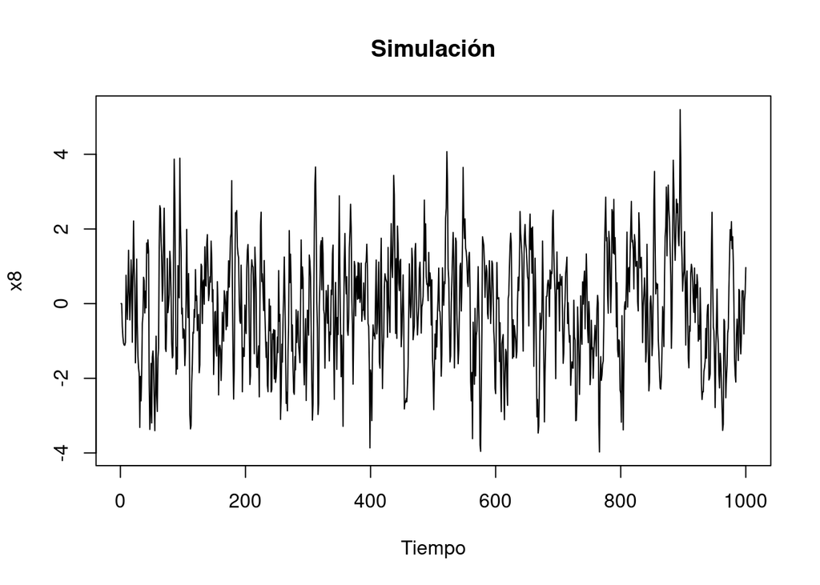

```r
# Para simular (4.25)
n <- 1000
x8 <- numeric(n)
w8 <- rnorm(n)

# Simulación manual
for (t in 3:n) {
  x8[t] <- (5/6) * x8[t - 1] - (1/6) * x8[t - 2] + w8[t]
}

# Para observar la simulación
plot(x8, type = "l", main = "Simulación", ylab = "x8", xlab = "Tiempo")
```

**b)** Grafica el correlograma y el correlograma parcial de los datos simulados. Comenta las gráficas.

## Respuesta

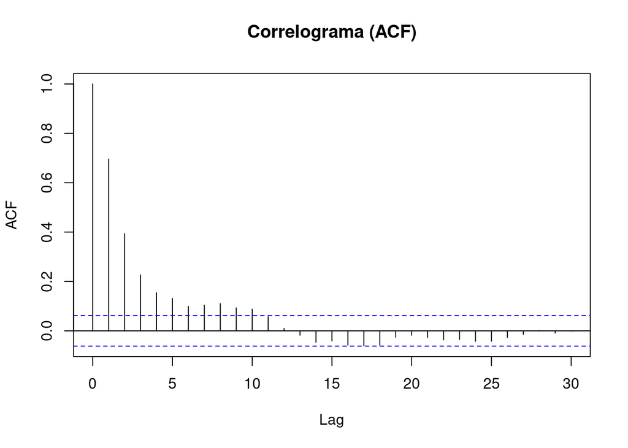

```r
acf(x8, main = "Correlograma (ACF)")
```

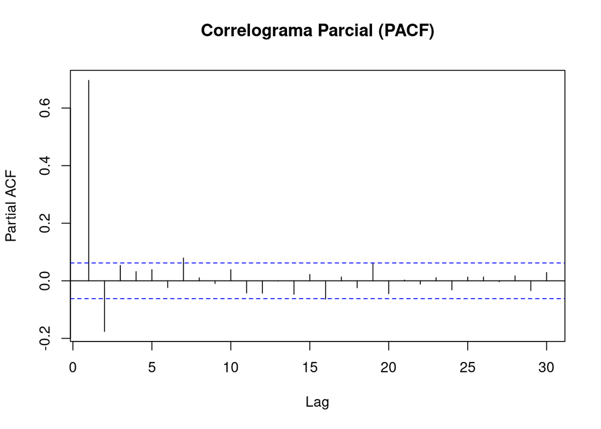

```r
pacf(x8, main = "Correlograma Parcial (PACF)")
```

*Comentario:* La ACF muestra un decaimiento gradual característico de un AR(2). La PACF muestra dos rezagos claramente significativos, lo que concuerda con un modelo AR de orden 2.

**c)** Ajusta un modelo autorregresivo a los datos contenidos en `x`, indicando los parámetros estimados y el orden del modelo AR ajustado.

## Respuesta

```r
modelo8 <- ar(x8, method = "mle")
modelo8$order       # Orden del modelo ajustado
```

```
## [1] 7
```

```r
modelo8$ar          # Coeficientes estimados
```

```
## [1]  0.827785620 -0.218797361  0.037451733 -0.009758877  0.076652794
## [6] -0.089904441  0.079551176
```

**d)** Construye intervalos de confianza del 95% para los parámetros estimados del modelo ajustado. ¿Los parámetros verdaderos están dentro de estos intervalos? Explica tus resultados.

## Respuesta

```r
est <- modelo8$ar
se <- sqrt(diag(modelo8$asy.var.coef))

ICs <- cbind(
  est - 1.96 * se,
  est + 1.96 * se
)
colnames(ICs) <- c("LI 95%", "LS 95%")
ICs
```

```
##            LI 95%       LS 95%
## [1,]  0.766024445  0.889546794
## [2,] -0.298883823 -0.138710899
## [3,] -0.043634623  0.118538090
## [4,] -0.090875114  0.071357360
## [5,] -0.004433562  0.157739151
## [6,] -0.169990903 -0.009817979
## [7,]  0.017790001  0.141312351
```

*Comentario:* Podemos comparar estos intervalos con los valores reales del modelo: $\alpha_1 = 5/6 \approx 0.833$ y $\alpha_2 = -1/6 \approx -0.167$. Si estos valores están dentro de los intervalos, entonces el ajuste es coherente.

**e)** ¿Es el modelo en la ecuación (4.25) estacionario o no estacionario? Justifica tu respuesta.

## Respuesta

El modelo es estacionario si las raíces del polinomio característico:
$$1 - \frac{5}{6}B + \frac{1}{6}B^2 = 0$$
tienen módulo mayor a 1. Esto puede comprobarse resolviendo la ecuación o aplicando `polyroot()`.

```r
raices <- polyroot(c(1, -5/6, 1/6))
Mod(raices)  # Deben ser > 1
```

```
## [1] 2 3
```

*Comentario:* Como ambas raíces tienen módulo mayor a 1, el modelo es estacionario.

# Ejercicio 5

## **a)**

Demuestra que la serie $\{x_t\}$ dada por:

$$x_t = \frac{3}{2}x_{t-1} - \frac{1}{2}x_{t-2} + w_t$$

es no estacionaria.

### Respuesta

Calculamos las raíces:

```r
raices <- polyroot(c(1, -3/2, 1/2))
Mod(raices)
```

```
## [1] 1 2
```

*Comentario:* Una de las raíces tiene módulo igual a 1, por lo tanto, el proceso no es estacionario.

## **b)**

Escribe el modelo para la serie $\{y_t\}$, donde $y_t = \nabla x_t = x_t - x_{t-1}$. Demuestra que $\{y_t\}$ es estacionaria.

### Respuesta

Aplicamos la primera diferencia:
$$y_t = x_t - x_{t-1} = (\frac{3}{2}x_{t-1} - \frac{1}{2}x_{t-2} + w_t) -
x_{t-1} = \frac{1}{2}x_{t-1} - \frac{1}{2}x_{t-2} + w_t$$

Es decir:
$$y_t = \frac{1}{2}x_{t-1} - \frac{1}{2}x_{t-2} + w_t$$

```r
raices_y <- polyroot(c(1, -1/2, 1/2))
Mod(raices_y)
```

```
## [1] 1.414214 1.414214
```

## **c)**

Simula una serie de 1000 valores para $\{x_t\}$, y coloca los datos simulados en un vector llamado `x`. Usa estos valores para producir una serie de 999 valores para $\{y_t\}$, y colócala en un vector llamado `y`.

### Respuesta

```r
n <- 1000
x9 <- numeric(n)
w9 <- rnorm(n)

for (t in 3:n) {
  x9[t] <- (3/2) * x9[t - 1] - (1/2) * x9[t - 2] + w9[t]
}

# Primera diferencia
y <- diff(x9)
```

**d)** Ajusta un modelo AR a la serie `y`. Da los parámetros estimados del modelo ajustado y un intervalo de confianza del 95% para cada parámetro. Compara estos intervalos con los parámetros utilizados para simular los datos y explica los resultados.

```r
modelo_y <- ar(y, method = "mle")
modelo_y$order      # Orden estimado
```

```
## [1] 1
```

```r
modelo_y$ar         # Coeficientes estimados
```

```
## [1] 0.4996815
```

```r
# Intervalos de confianza del 95%
est <- modelo_y$ar
se <- sqrt(diag(modelo_y$asy.var.coef))
ICs <- cbind(est - 1.96 * se, est + 1.96 * se)
colnames(ICs) <- c("LI 95%", "LS 95%")
ICs
```

```
##         LI 95%    LS 95%
## [1,] 0.4459826 0.5533805
```

# Ejercicio 6

## **a)**

Ajusta nuevamente el modelo AR(4) de la Sección 4.6.3 a la serie de temperaturas medias anuales globales, y utilizando el modelo ajustado, genera una serie de valores predichos desde $t = 2$ hasta el último valor de la serie (usando la Ecuación 4.24). Crea una serie de residuos como la diferencia entre los valores predichos y los observados, y verifica que, dentro de la precisión de máquina, esa serie de residuos es idéntica a la obtenida con el modelo ajustado en R.

### Respuesta

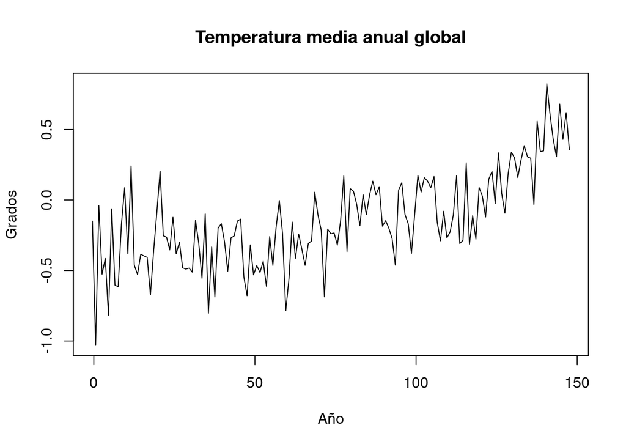

```r
global <- read.table("global.dat", header = TRUE)

temp <- ts(global[, 2], start = global[1, 1])  # Asume que la columna 1 es el año y la 2 la temperatura
plot.ts(temp, main = "Temperatura media anual global", ylab = "Grados", xlab = "Año")
```

```r
modelo_ar4 <- ar(temp, order.max = 4, method = "mle")
coeficientes <- modelo_ar4$ar

# Predicciones usando la ecuación del modelo ajustado
n <- length(temp)
pred <- numeric(n)
for (t in 5:n) {
  pred[t] <- sum(coeficientes * temp[(t-1):(t-4)])
}

# Residuos manuales
residuos_manual <- temp - pred
```

## **b)**

Grafica el correlograma y el correlograma parcial de la serie de temperaturas medias anuales. Comenta las gráficas.

### Respuesta

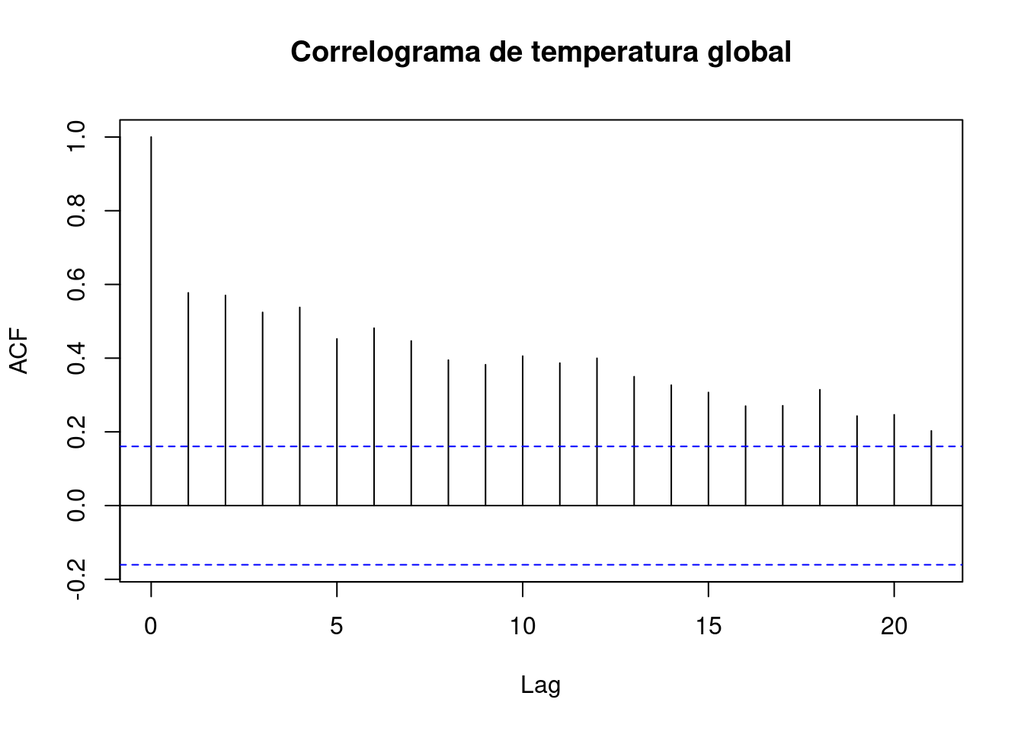

```r
acf(temp, main = "Correlograma de temperatura global")
```

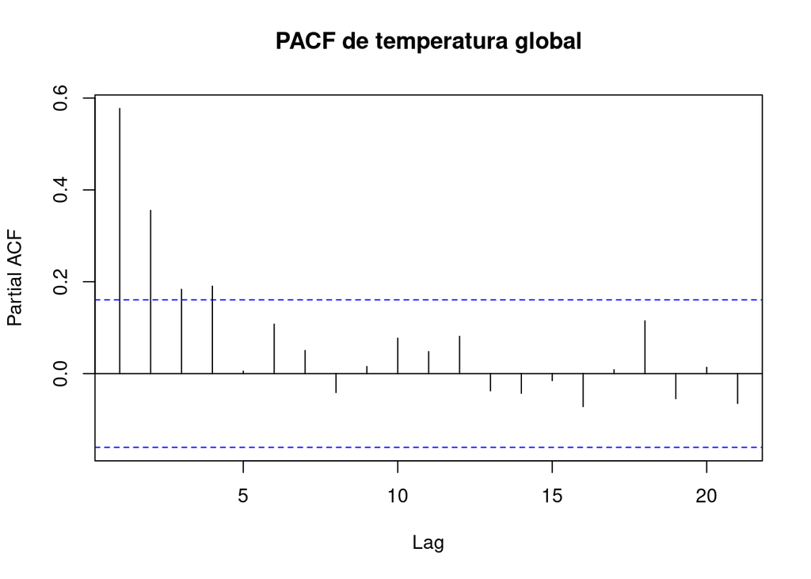

```r
pacf(temp, main = "PACF de temperatura global")
```

*Comentario:* El correlograma parcial muestra un corte claro en el rezago 4, lo que es coherente con un modelo AR(4).

## **c)**

Usa la función `predict()` en R para pronosticar 100 años futuros de la serie de temperaturas usando el modelo AR(4) ajustado (Ecuación 4.24 de la Sección 4.6.3).

### Respuesta

```r
forecast <- predict(modelo_ar4, n.ahead = 100)
pred_100 <- forecast$pred
error_100 <- forecast$se
```

## **d)**

Genera un gráfico de la serie de temperaturas medias anuales y agrega los pronósticos a 100 años en el mismo gráfico (usa un color o símbolo diferente para los pronósticos).

### Respuesta

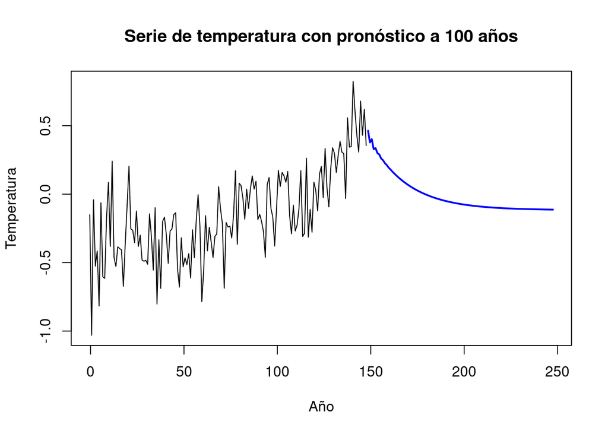

```r
time_future <- (end(temp)[1] + 1):(end(temp)[1] + 100)

plot(temp, xlim = c(start(temp)[1], end(temp)[1] + 100),
     main = "Serie de temperatura con pronóstico a 100 años",
     ylab = "Temperatura", xlab = "Año")

lines(time_future, pred_100, col = "blue", lwd = 2)
```